# MATH1324 Assignment 1

Modeling Body Measurements

## Student Details

Student Name: Chih-Ying,Ho (s3816723)

## Problem Statement

Manufacturers decide to produce knee pads for those who enjoy excercising. However, manufacturers have no idea about the size of people’s. In this report, I investigated whether people’s knee diameters fit the normal distribution or not. This gives suppliers the information about the distribution and probabolity of people’s knee diameters.The approach is that I applied QQ plot and Shapiro Wilk’s test to check whether the vaiable call kne.gi is normal distribution or not, then I plotted histogram with normal distribution overlay to verify again.

## Load Packages

```r
# This is a chunk where you can load the necessary packages required to reproduce the report
library(readr)
library(magrittr)
library(dplyr)
```

## Data

Import the body measurements data and prepare it for analysis. Show your code.

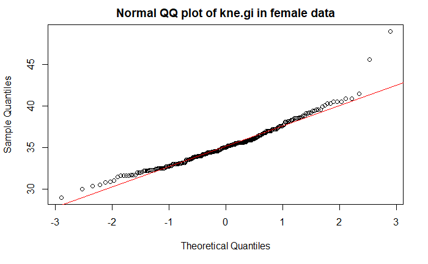

```r
# This is a chunk for your Data section.
data <- read.csv("C:/Users/joy/Documents/bdims.csv")
data_f <- filter(data, data$sex == 0)
data_m <- filter(data, data$sex == 1)
#  investigate if this measurement fits a normal distribution
# QQ plot
qqnorm(data_f$kne.gi, main = "Normal QQ plot of kne.gi in female data")
qqline(data_f$kne.gi, col = 'red')
```

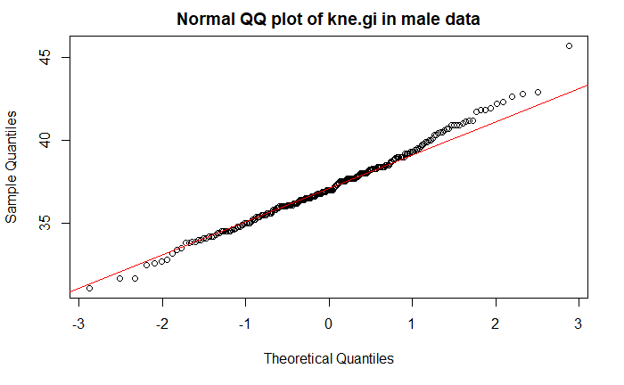

```r
qqnorm(data_m$kne.gi, main="Normal QQ plot of kne.gi in male data")
qqline(data_m$kne.gi, col = 'red')
```

```r
# Shapiro Wilk’s test
shapiro.test(data_f$kne.gi)
```

```
    Shapiro-Wilk normality test

data:  data_f$kne.gi
W = 0.9541, p-value = 2.572e-07
```

```r
shapiro.test(data_m$kne.gi)
```

```
    Shapiro-Wilk normality test

data:  data_m$kne.gi
W = 0.99141, p-value = 0.1572
```

```r
# define the variable sex as a factor and define labels
data$sex <- factor(data$sex, levels = c(1,0),
                   labels = c("Male","Female"))
```

## Summary Statistics

Calculate descriptive statistics (i.e., mean, median, standard deviation, first and third quartile, interquartile range, minimum and maximum values) of the selected measurement grouped by sex.

```r
# This is a chunk for your Summary Statistics section.
summarise(group_by(data,sex),
          Mean = mean(kne.gi),
          Median = median(kne.gi),
          SD = sd(kne.gi),
          Q1 = quantile(kne.gi, probs = 0.25),
          Q3 = quantile(kne.gi, probs = 0.75),
          IQR = IQR(kne.gi),
          Min = min(kne.gi),
          Max = max(kne.gi))
```

| sex | Mean | Median | SD | Q1 | Q3 | IQR | Min | Max |
| --- | --- | --- | --- | --- | --- | --- | --- | --- |
| Male | 37.19555 | 37 | 2.272999 | 35.75 | 38.45 | 2.7 | 31.1 | 45.7 |
| Female | 35.26000 | 35 | 2.578081 | 33.50 | 36.80 | 3.3 | 29.0 | 49.0 |

## Distribution Fitting

Compare the empirical distribution of selected body measurement to a normal distribution separately in men and in women. You need to do this visually by plotting the histogram with normal distribution overlay. Show your code.

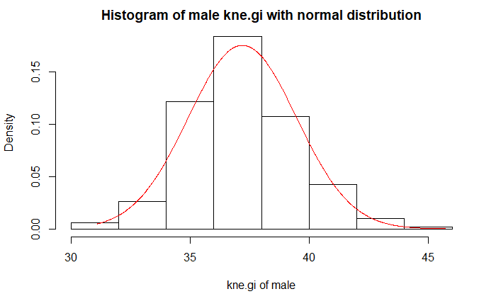

```r
# This is a chunk for your Distribution Fitting section.
# male data of kne.gi
hist(data_m$kne.gi,
     probability=T,
     breaks = 10,
     main="Histogram of male kne.gi with normal distribution",
     xlab="kne.gi of male")
lines(seq(min(data_m$kne.gi),
                max(data_m$kne.gi),
                length = 1000),
      dnorm(seq(min(data_m$kne.gi),
                max(data_m$kne.gi),
                length = 1000),
            mean(data_m$kne.gi),
            sd(data_m$kne.gi)),
      col = "red",
      )
```

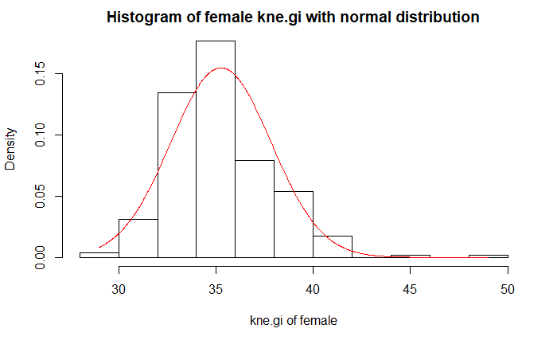

```r
# female data of kne.gi
hist(data_f$kne.gi,
     probability=T,
     breaks = 10,
     main="Histogram of female kne.gi with normal distribution",
     xlab="kne.gi of female")
lines(seq(min(data_f$kne.gi),
                max(data_f$kne.gi),
                length = 1000),
      dnorm(seq(min(data_f$kne.gi),
                max(data_f$kne.gi),
                length = 1000),
            mean(data_f$kne.gi),
            sd(data_f$kne.gi)),
      col = "red",
      )
```

## Interpretation

The result reveals that, to man, the empirical data is similar the theoretical normal distribution, which means that roughly 68% of knee size is within one standard deviation of the mean. I recommend that manufacturers produce male knee pads with the size between 35 and 39 the most. In terms of women, although the empirical data does not fit the theoretical normal distribution, the peak of empirical data is 35, which is same as theoretical normal distribution. I recommend that manufacturers produce female knee pads the most.